# Data Access in R - Part 2

Johnathan Evanilla

8/10/2022

# [National Data Buoy Center](https://www.ndbc.noaa.gov/)

To read [NDBC](https://www.ndbc.noaa.gov/) data we suggest that you use the [rnoaa](https://docs.ropensci.org/rnoaa/) package from [rOpenSci](https://ropensci.org/).

### Requirements

You only need the [rnoaa](https://docs.ropensci.org/rnoaa/) package to get data, but we include helper packages, `dplyr` and `ggplot2`, for the purpose of this tutorial.

```r
suppressPackageStartupMessages({
  required <- c("dplyr", "ggplot2", "rnoaa")
  installed <- installed.packages() |>
    dplyr::as_tibble()
  needed <- !(required %in% installed$Package)
  if (any(needed)){
    install.packages(required[needed])
  }
  ok <- sapply(required, library, character.only = TRUE)
})
```

### Generate a list of buoys, and, as an example, narrow the list to Gulf of Maine.

```r
bb <- c(xmin = -72, xmax = -63, ymin = 39, ymax = 46)
buoys <- buoy_stations() |>
  filter(between(lat, bb['ymin'], bb['ymax']),
         between(lon, bb['xmin'], bb['xmax']))

glimpse(buoys)
```

```
## Rows: 65
## Columns: 12
## $ station         <chr> "44003", "44005", "44007", "44008", "44011", "44013", …
## $ lat             <dbl> 40.800, 43.201, 43.525, 40.504, 41.098, 42.346, 42.119…
## $ lon             <dbl> -68.500, -69.128, -70.141, -69.248, -66.619, -70.651, …
## $ viewport        <chr> "width=device-width, initial-scale=1.0", "width=device…
## $ DC.title        <chr> "NDBC Station Page", "NDBC Station Page", "NDBC Statio…
## $ DC.description  <chr> "National Data Buoy Center - Recent observations from …
## $ description     <chr> "National Data Buoy Center - Recent observations from …
## $ DC.subject      <chr> "weather, buoy, weather buoy, marine, forecast, hurric…
## $ DC.creator      <chr> "US Department of Commerce, National Oceanic and Atmos…
## $ DC.language     <chr> "EN-US", "EN-US", "EN-US", "EN-US", "EN-US", "EN-US", …
## $ DC.format       <chr> "text/html;charset=iso-8859-1", "text/html;charset=iso…
## $ DC.date.created <chr> "1996-11-08", "1996-11-08", "1996-11-08", "1996-11-08"…
```

```r
CFW_id <- buoys |>
filter(grepl("Portland", description, fixed = TRUE))

glimpse(CFW_id)
```

```
## Rows: 2
## Columns: 12
## $ station         <chr> "44007", "CASM1"
## $ lat             <dbl> 43.525, 43.656
## $ lon             <dbl> -70.141, -70.246
## $ viewport        <chr> "width=device-width, initial-scale=1.0", "width=device…
## $ DC.title        <chr> "NDBC Station Page", "NDBC Station Page"
## $ DC.description  <chr> "National Data Buoy Center - Recent observations from …
## $ description     <chr> "National Data Buoy Center - Recent observations from …
## $ DC.subject      <chr> "weather, buoy, weather buoy, marine, forecast, hurric…
## $ DC.creator      <chr> "US Department of Commerce, National Oceanic and Atmos…
## $ DC.language     <chr> "EN-US", "EN-US"
## $ DC.format       <chr> "text/html;charset=iso-8859-1", "text/html;charset=iso…
## $ DC.date.created <chr> "1996-11-08", "1996-11-08"
```

### Now we can pull buoy data, but only one dataset, such as standard meteorology, for a single year at a time may be requested. The function yields a list of two elements…

- `meta` a list variable descriptions
- `data` a data frame (tibble) with reported data

```r
stdmet <- buoy("stdmet", CFW_id$station[1], year = 2021)
names(stdmet)
```

```
## [1] "meta" "data"
```

```r
glimpse(stdmet$data)
```

```
## Rows: 51,558
## Columns: 16
## $ time                    <chr> "2021-01-01T00:00:00Z", "2021-01-01T00:10:00Z"…
## $ lat                     <dbl> 43.525, 43.525, 43.525, 43.525, 43.525, 43.525…
## $ lon                     <dbl> -70.14, -70.14, -70.14, -70.14, -70.14, -70.14…
## $ wind_dir                <int> 322, 317, 319, 318, 320, 319, 324, 331, 327, 3…
## $ wind_spd                <dbl> 6.9, 6.2, 5.6, 5.6, 5.1, 5.2, 4.6, 5.6, 5.2, 4…
## $ gust                    <dbl> 9.1, 8.6, 7.9, 6.9, 6.4, 6.5, 6.1, 7.9, 7.1, 6…
## $ wave_height             <dbl> NA, NA, NA, NA, 0.82, NA, NA, NA, NA, NA, 0.79…
## $ dominant_wpd            <dbl> NA, NA, NA, NA, 10.00, NA, NA, NA, NA, NA, 7.6…
## $ average_wpd             <dbl> NA, NA, NA, NA, 6.08, NA, NA, NA, NA, NA, 5.62…
## $ mean_wave_dir           <int> NA, NA, NA, NA, 155, NA, NA, NA, NA, NA, 137, …
## $ air_pressure            <dbl> 1022.4, 1022.6, 1022.8, 1022.9, 1023.2, 1023.2…
## $ air_temperature         <dbl> 4.0, 3.8, 3.7, 3.6, 3.6, 3.5, 3.5, 3.5, 3.4, 3…
## $ sea_surface_temperature <dbl> 7.0, 7.1, 7.0, 7.0, 7.0, 7.0, 7.0, 7.0, 7.0, 6…
## $ dewpt_temperature       <dbl> -5.1, -5.6, -5.8, -5.9, -5.8, -6.0, -5.7, -5.8…
## $ visibility              <dbl> NA, NA, NA, NA, NA, NA, NA, NA, NA, NA, NA, NA…
## $ water_level             <dbl> NA, NA, NA, NA, NA, NA, NA, NA, NA, NA, NA, NA…
```

### With just a little manipulation, we can start viewing the data graphically. First we must convert the timestamp data from character to numeric, specifically a POSIX timestamp (seconds of time since that start of an arbitrary origin, in this case 1970-01-01 00:00:00).

```r
stdmet$data <- mutate(stdmet$data, time = as.POSIXct(time, format = "%Y-%m-%dT%H:%M:%SZ"))
```

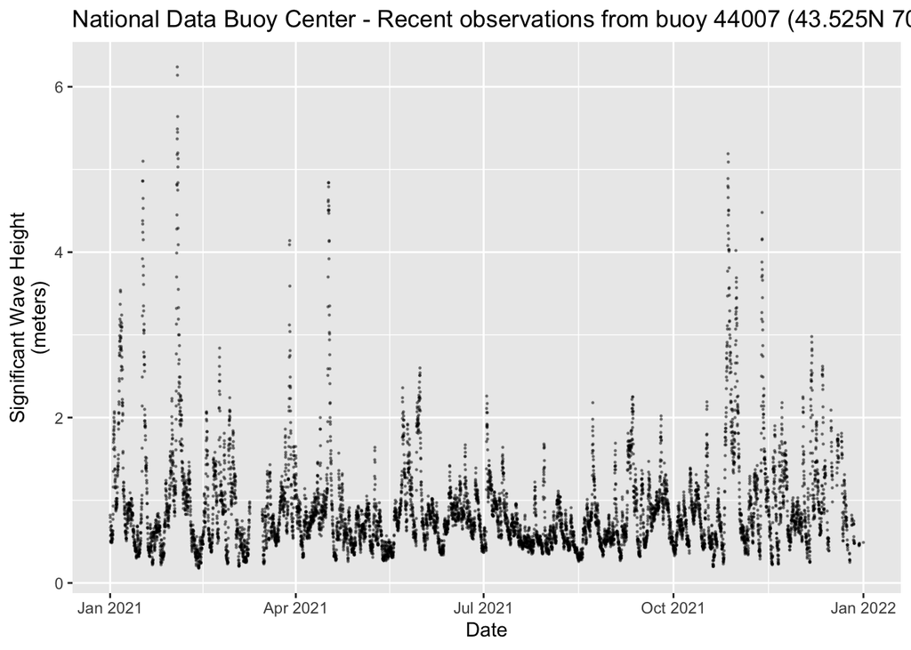

```r
wave_meta <- stdmet$meta$wave_height

ggplot(data = stdmet$data,
       aes(x = time,
           y = wave_height)) +
  geom_point(size = 0.2, alpha = 0.4) +
  labs(title = sub("National Data Buoy Center - Recent observations from station ",
                   "",
                   CFW_id$description),
       y = sprintf("%s\n(%s)", wave_meta$longname, wave_meta$units),
       x = "Date")
```